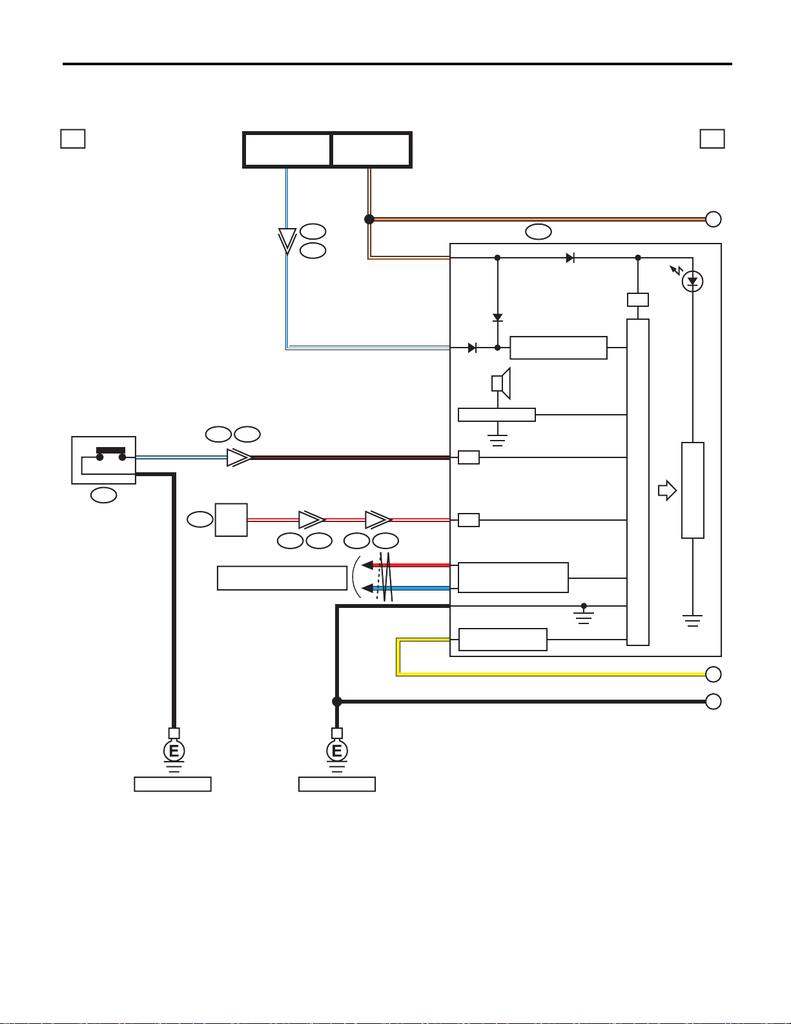

Seat Belt Warning System

WIRING SYSTEM

47.Seat Belt Warning System

A: WIRING DIAGRAM

a a

3

3

16

WI-44559

i10

B

I/F

I/F

I/F

A

C

i229

B551

R108

AB6

i102R167

i230B552

7

BR/W

20

38B

W/L

BR/W

W/L

BR/W

40

R33

L32

B

28Y

Y

B

R/W 16

B/R 15

W/L

W/L

2

L/W

B

B

L/W B/R1

R/WA15

R/W

A:

AIRBAG CM

SEAT BELT

SWITCH LH

REF. TO CAN COMMUNICATION

SYSTEM [b]

MICRO COMPUTER

SEAT BELT

(DRIVER'S SEAT)

SPEAKER

FB-18

F/B FUSE NO. 7

(B)

FB-12

F/B FUSE NO. 2

(IG)

REF. TO GND [f] REF. TO GND [e]

DRIVE CIRCUIT

CAN TRANSCEIVER &

RECEIVER

DRIVE CIRCUIT

DRIVE CIRCUIT

POWER SUPPLY

CIRCUIT

COMBINATION METER

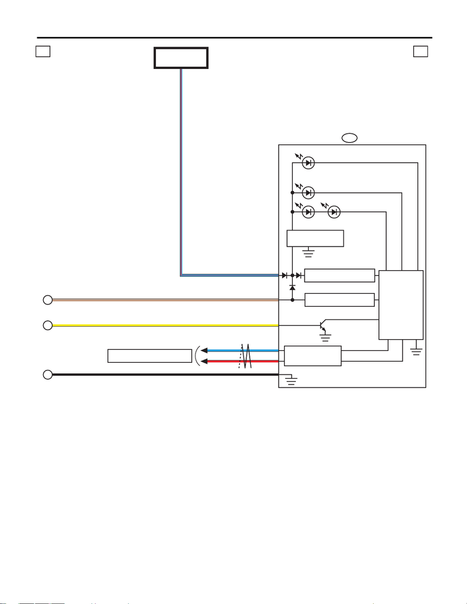

Seat Belt Warning System

WIRING SYSTEM

WI-44560

b b

A:

A

B

C

MFD

i122

BA2

YA9

A1

BR/W

B

Y

BR/W A3

L/R

L/R

A5

A6R

L

REF. TO CAN COMMUNICATION

SYSTEM [b]

SEAT BELT

(PASSENGER'S SEAT)

MICRO

COMPUTER

FB-10

M/B FUSE NO. 8

(B)

CONSTANT VOLTAGE

CIRCUIT

CAN TRANSCEIVER &

RECEIVER

IG DETECTING

CIRCUIT

CONSTANT VOLTAGE

CIRCUIT

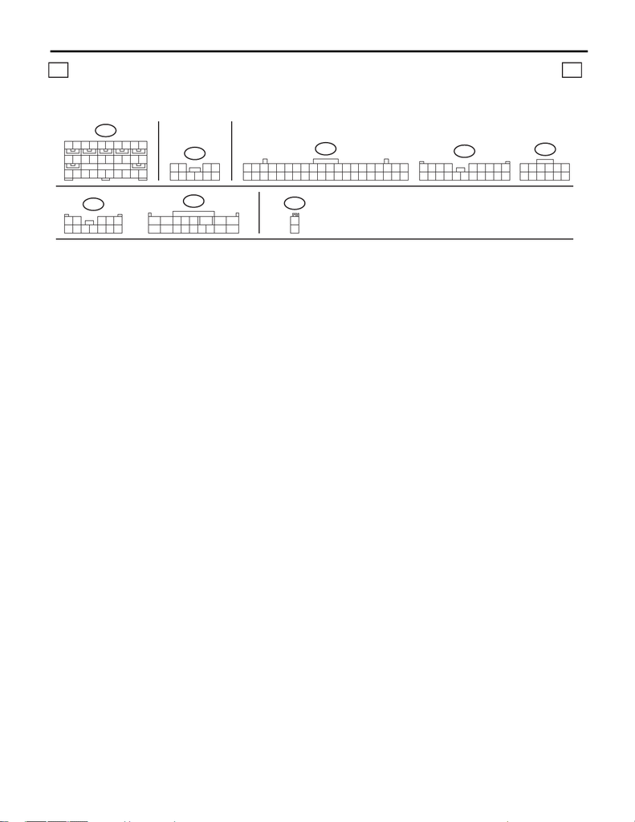

Seat Belt Warning System

WIRING SYSTEM

WI-44561

c c

8

9

10

11 12 13 14

15 16 17 18 19 20

21 22 23 24 25 26 27 28 29 30

AB6

(Y)

A:

i10

11 12

9

10

2

18

20

21 22 23 24 26

25

27 28 29 30 31 32 33 34 35 36 37 38 39 40

17

89

19 20

10 11 12 13 14 15 16 17 18

i102

11 12

9

10

78

2

i122

(B)

A:

i230

(GR)

10

13

345 6

14 15 16 17

1211

12 78

9

(GR)

B31

8765

21

10

9

43

1

2

R108

i229

12 345

6789

10 11 12

LIST OF CONNECTORS